# Untitled

Sijuade Oguntayo

Sunday, May 10, 2015

## Introduction

The emissions dataset consists of a number variables hand picked by me and wrangled and merged from 11 different datasets all downloaded from the Gapminder or Databank websites. I chose this dataset for my project because I am working on something similar for the Data Visualization with D3 Module on the same Nanodegree, the visualization can be viewed at http://sijvizproject.esy.es/ (note that the visualization is not ready yet and is still being developed)

With everything in the news about global warming, I hoped to investigate for myself based on publicly available data. Since I at the start of this project knew little to nothing about global warming, my goal for this project is to educate myself on it.

From the very start, Emissions yearly and Emissions capita I felt should be the variables of interest and all subsequent analysis will be baed around them, I will include a univariate section using histograms, a bivariate using a number of plot types and finally a multivariate section typically using Continent the only categorical variable I added to the dataset. The plan is to then build a predictive model if possible and see if I can predict either the emissions yearly or capita given a number of features.

# Dataset summaries

```
##        X             Country          Year       Populations
##  Min.   :   1   Algeria  :  52   Min.   :1960   Min.   :8.092e+03
##  1st Qu.:1762   Argentina:  52   1st Qu.:1973   1st Qu.:1.281e+06
##  Median :3522   Australia:  52   Median :1987   Median :5.528e+06
##  Mean   :3522   Austria  :  52   Mean   :1986   Mean   :3.097e+07
##  3rd Qu.:5283   Brazil   :  52   3rd Qu.:1999   3rd Qu.:1.577e+07
##  Max.   :7044   Bulgaria :  52   Max.   :2011   Max.   :1.348e+09
##                 (Other)  :6732
##  Emissions_Yearly_Total Emissions_Capita      Global_Pop
##  Min.   :      4        Min.   :  0.00056   Min.   :2.088e+10
##  1st Qu.:    748        1st Qu.:  0.38090   1st Qu.:2.695e+10
##  Median :   5020        Median :  1.56098   Median :3.451e+10
##  Mean   : 119426        Mean   :  4.55689   Mean   :3.427e+10
##  3rd Qu.:  49670        3rd Qu.:  6.41965   3rd Qu.:4.155e+10
##  Max.   :9110979        Max.   :101.94495   Max.   :4.822e+10
##
##          Continent       Literacy       Access_Elec         Forest
##  Africa       :1952   Min.   : 8.685   Min.   :  0.10   Min.   : 0.00
##  Asia         :1536   1st Qu.:64.192   1st Qu.: 48.86   1st Qu.:10.60
##  Australia    : 589   Median :86.751   Median : 90.90   Median :27.04
##  Europe       :1425   Mean   :76.538   Mean   : 73.41   Mean   :29.73
##  North America: 930   3rd Qu.:93.510   3rd Qu.:100.00   3rd Qu.:46.69
##  South America: 612   Max.   :99.816   Max.   :100.00   Max.   :94.72
##                       NA's   :6652     NA's   :6699     NA's   :3919
##       GDP              Energy_Use         Alternate
##  Min.   :9.123e+06   Min.   :   43.23   Min.   : 0.000
##  1st Qu.:1.280e+09   1st Qu.:  547.85   1st Qu.: 0.439
##  Median :6.386e+09   Median : 1265.35   Median : 2.719
##  Mean   :1.621e+11   Mean   : 2313.34   Mean   : 7.946
##  3rd Qu.:4.720e+10   3rd Qu.: 3136.83   3rd Qu.:10.021
##  Max.   :1.552e+13   Max.   :23109.76   Max.   :99.454
##  NA's   :817         NA's   :2706       NA's   :2821
```

```
## 'data.frame':    7044 obs. of  14 variables:
##  $ X                     : int  1 2 3 4 5 6 7 8 9 10 ...
##  $ Country               : Factor w/ 155 levels "Afghanistan",..: 1 1 1 1 1 1 1 1 1 1 ...
##  $ Year                  : int  1960 1961 1962 1963 1964 1965 1966 1967 1968 1969 ...
##  $ Populations           : int  9671046 9859928 10056480 10261254 10474903 10697983 10927724 11163656 11411022 11676990 ...
##  $ Emissions_Yearly_Total: num  414 491 689 708 840 ...
##  $ Emissions_Capita      : num  0.0428 0.0498 0.0685 0.069 0.0802 ...
##  $ Global_Pop            : num  2.09e+10 2.12e+10 2.15e+10 2.20e+10 2.24e+10 ...
##  $ Continent             : Factor w/ 6 levels "Africa","Asia",..: 2 2 2 2 2 2 2 2 2 2 ...
##  $ Literacy              : num  NA NA NA NA NA NA NA NA NA NA ...
##  $ Access_Elec           : num  NA NA NA NA NA NA NA NA NA NA ...
##  $ Forest                : num  NA NA NA NA NA NA NA NA NA NA ...
##  $ GDP                   : num  5.38e+08 5.49e+08 5.47e+08 7.51e+08 8.00e+08 ...
##  $ Energy_Use            : num  NA NA NA NA NA NA NA NA NA NA ...
##  $ Alternate             : num  NA NA NA NA NA NA NA NA NA NA ...
```

```
##   X     Country Year Populations Emissions_Yearly_Total Emissions_Capita
## 1 1 Afghanistan 1960     9671046               414.3333       0.04284266
## 2 2 Afghanistan 1961     9859928               491.3333       0.04983133
## 3 3 Afghanistan 1962    10056480               689.3333       0.06854618
## 4 4 Afghanistan 1963    10261254               707.6667       0.06896493
## 5 5 Afghanistan 1964    10474903               839.6667       0.08015985
## 6 6 Afghanistan 1965    10697983              1008.3333       0.09425453
##    Global_Pop Continent Literacy Access_Elec Forest        GDP Energy_Use
## 1 20883850512      Asia       NA          NA     NA  537777812         NA
## 2 21162222957      Asia       NA          NA     NA  548888895         NA
## 3 21524875241      Asia       NA          NA     NA  546666678         NA
## 4 21971357583      Asia       NA          NA     NA  751111191         NA
## 5 22421532194      Asia       NA          NA     NA  800000046         NA
## 6 22881117323      Asia       NA          NA     NA 1006666638         NA
##   Alternate
## 1        NA
## 2        NA
## 3        NA
## 4        NA
## 5        NA
## 6        NA
```

# Univariate Analysis

Histograms Emissions Yearly Histogram

This seems to be very right skewed with lots of outliers however, A log transformation makes it more normally distributed. Adding the continent variable shows a clear pattern in how different continents contribute to global emission. African countries generally contribute the least with not a lot of variation, Asian countries show a lot of variation from not contributing a lot to contributing a very high amount, this is to be expected taking into account countries like China but just as in the case with Africa, many of the countries are under-developed and would contribute little to emission. Europe shows most of it’s countries contributing a fair bit with a handful of contries contributing a lot for example, the UK, Germany and France. The histogram also appears to be bi-modal, many yearly emissions counts seem to fall within those ranges.

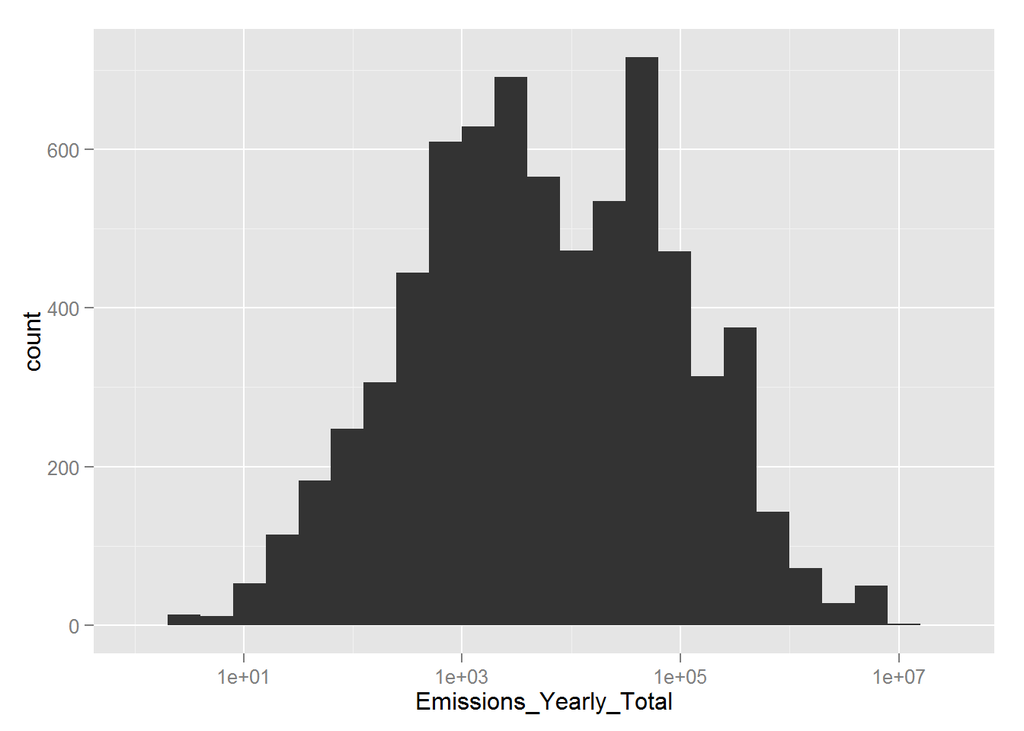

```
## Continent: Africa
##     Min.  1st Qu.   Median     Mean  3rd Qu.     Max.
##      3.7    399.7   1060.0  13090.0   3957.0 519300.0
## --------------------------------------------------------
## Continent: Asia
##    Min. 1st Qu.  Median    Mean 3rd Qu.    Max.
##       4    3638   22490  187000   81510 9111000
## --------------------------------------------------------
## Continent: Australia
##     Min.  1st Qu.   Median     Mean  3rd Qu.     Max.
##      7.3     66.0    198.0  24170.0   2009.0 400200.0
## --------------------------------------------------------
## Continent: Europe
##      Min.   1st Qu.    Median      Mean   3rd Qu.      Max.
##     293.3   17550.0   54850.0  144800.0  164100.0 1121000.0
## --------------------------------------------------------
## Continent: North America
##    Min. 1st Qu.  Median    Mean 3rd Qu.    Max.
##      11     407    1764  305200    8726 5828000
## --------------------------------------------------------
## Continent: South America
##     Min.  1st Qu.   Median     Mean  3rd Qu.     Max.
##    304.3   2392.0   9165.0  39280.0  44820.0 424400.0
```

Emissions Capita Just as in the case of Emissions yearly, emissions per capita is also right skewed, applying a logarithmic transformation makes the distribution more normal.

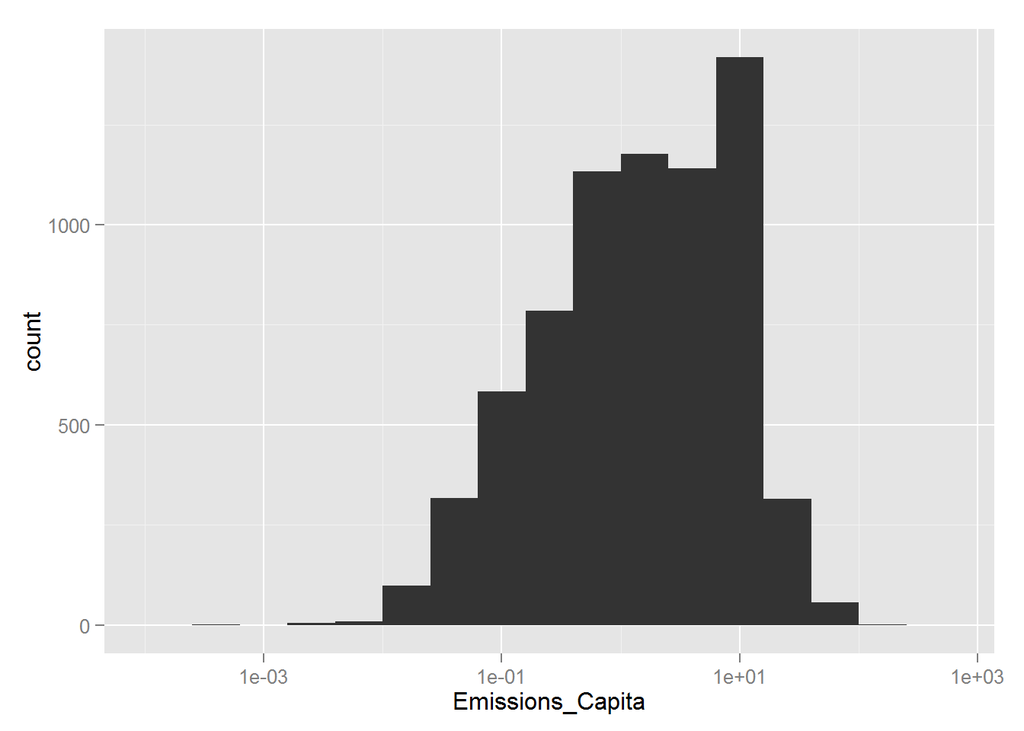

```
## Continent: Africa
##      Min.   1st Qu.    Median      Mean   3rd Qu.      Max.
##  0.000557  0.087680  0.231100  0.850400  0.731600 11.720000
## --------------------------------------------------------
## Continent: Asia
##      Min.   1st Qu.    Median      Mean   3rd Qu.      Max.
##   0.00451   0.54300   2.48400   7.37300   7.32500 101.90000
## --------------------------------------------------------
## Continent: Australia
##     Min.  1st Qu.   Median     Mean  3rd Qu.     Max.
##  0.08705  0.47020  0.88450  3.76500  6.18700 22.77000
## --------------------------------------------------------
## Continent: Europe
##    Min. 1st Qu.  Median    Mean 3rd Qu.    Max.
##  0.4542  5.4340  7.2930  7.9010  9.7730 40.5300
## --------------------------------------------------------
## Continent: North America
##     Min.  1st Qu.   Median     Mean  3rd Qu.     Max.
##  0.03892  0.62010  1.87600  4.79800  7.22300 29.84000
## --------------------------------------------------------
## Continent: South America
##    Min. 1st Qu.  Median    Mean 3rd Qu.    Max.
##  0.1597  1.1390  1.6390  1.9200  2.2090  6.5810
```

It is important to note that the histograms for both the emissions yearly and emissions capita are for the countries for all of the years and as a result, many countries are represented more than once for each year that we have data for that country. It might be helpful to draw histograms for one specific year though we should have a similar pattern for those as well.

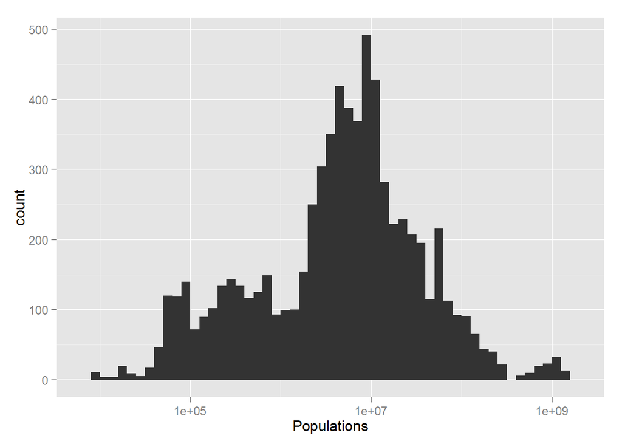

```
##      Min.   1st Qu.    Median      Mean   3rd Qu.      Max.
## 8.092e+03 1.281e+06 5.528e+06 3.097e+07 1.577e+07 1.348e+09
```

Country populations with a log scale applied results in normal looking distribution

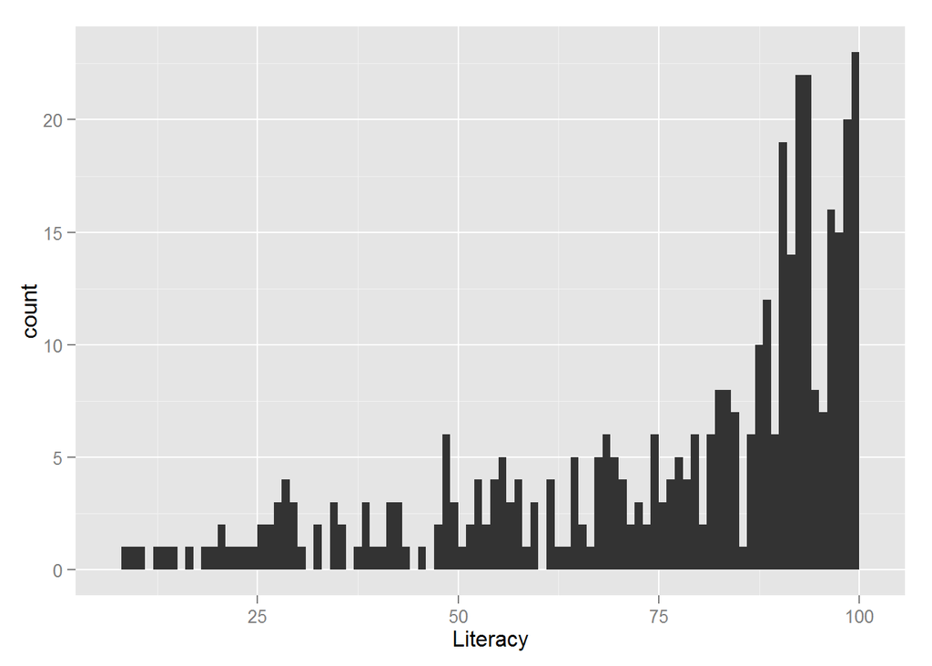

```
##    Min. 1st Qu.  Median    Mean 3rd Qu.    Max.    NA's
##   8.685  64.190  86.750  76.540  93.510  99.820    6652
```

This plot shows a left skewed distribution for the world’s literacy rate with a high count of countries on the right side with a high literacy rate. It would be interesting to view in the bivariate section how this varies by continent.

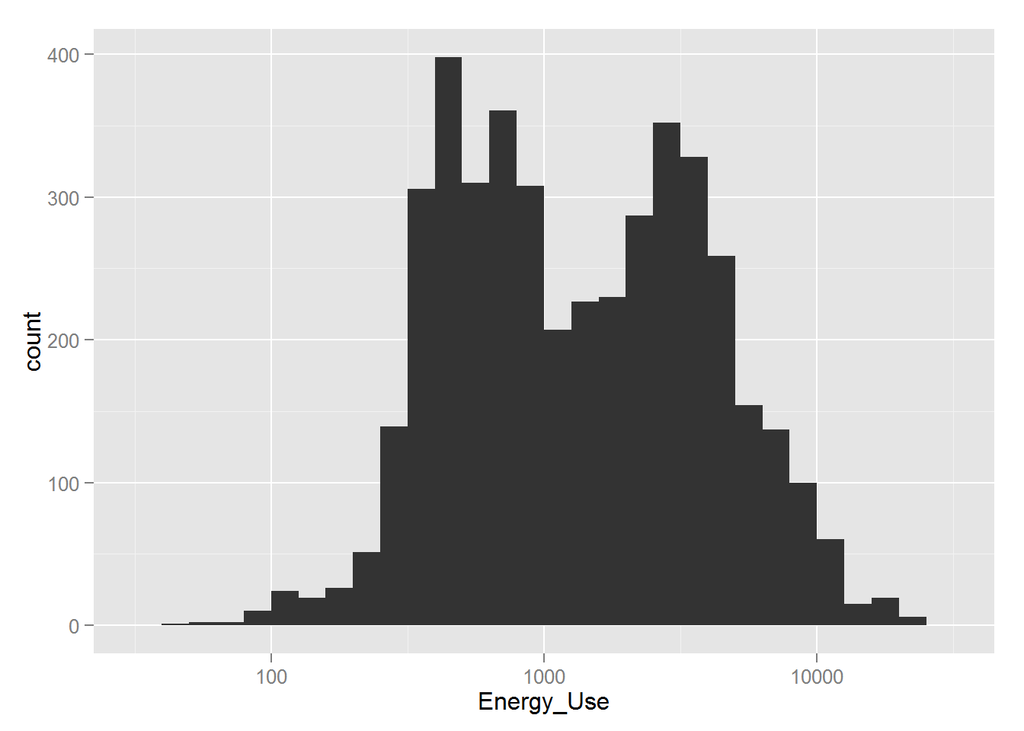

```
##     Min.  1st Qu.   Median     Mean  3rd Qu.     Max.
##    43.23   547.90  1265.00  2313.00  3137.00 23110.00
```

A histogram of Energy use shows a multimodal distribution, this twin peak represents the highest amount of energy used by the most count of countries for all the time. Just as in the previous case, Energy should also be explored in more detail in the bivariate section.

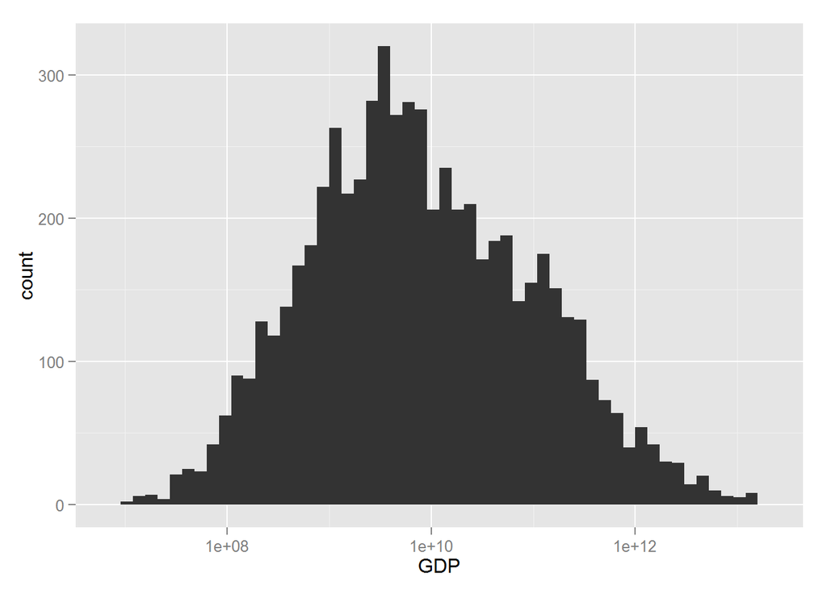

```
##      Min.   1st Qu.    Median      Mean   3rd Qu.      Max.
## 9.123e+06 1.280e+09 6.386e+09 1.621e+11 4.720e+10 1.552e+13
```

GDP also scaled logarithmically appears to be normally distributed.

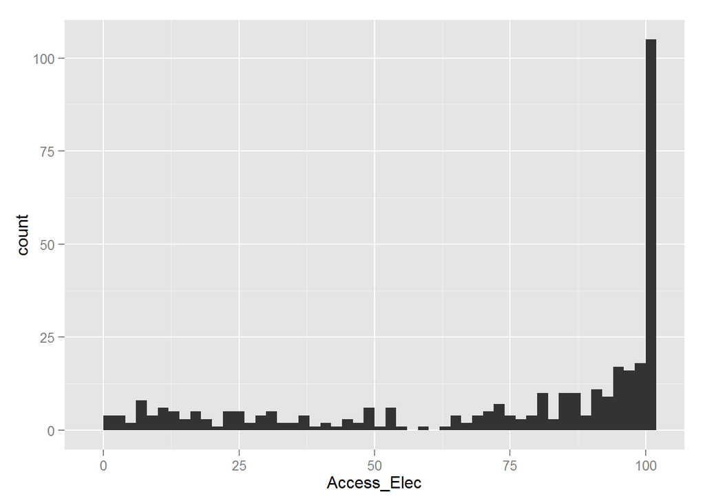

```
##    Min. 1st Qu.  Median    Mean 3rd Qu.    Max.
##    0.10   48.86   90.90   73.41  100.00  100.00
```

A good place to start is with a scatterplot matrix to show all the variables’ relationship to each other. Dataset is subset only for the year 2000 and some columns are excluded

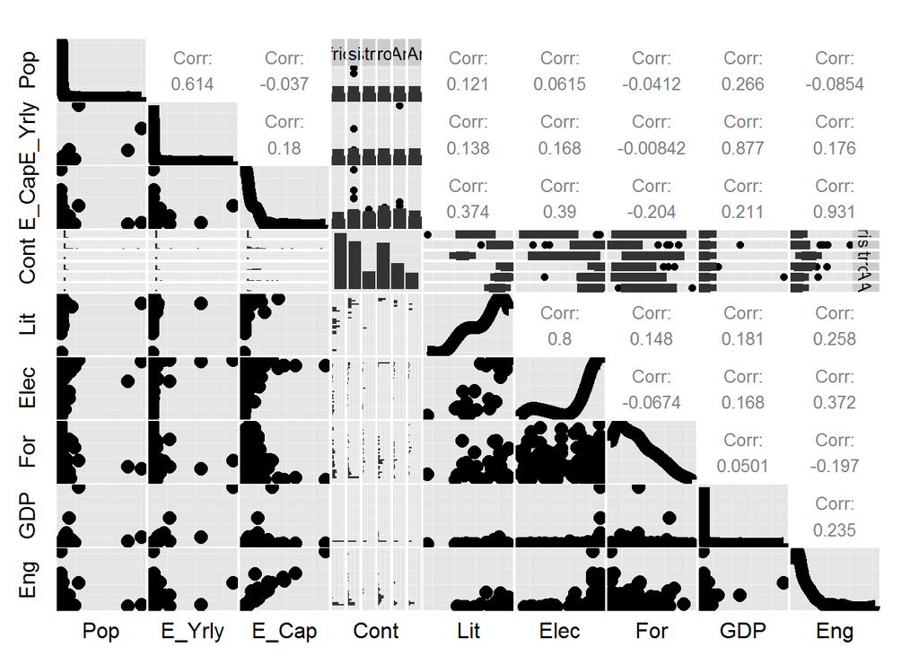

Right out of the box without any transformations, some variables look to be highly correlated. Populations and Emissions yearly Total with a correlation of 0.614, Literacy rate and access to electricity with 0.8, GDP and emissions yearly total, emission per capita with energy use. There are other relatively strong correlations though not as strong as the ones mentioned.

# Structure of the dataset

There are 7,044 observations in the dataset with 13 features(Country, Year, Populations, Emissions_Yearly_Total, Emissions_Capita, Global Population, Continent, Literacy % rate, percentage with access to electricty, % of land area with Forest, GDP, Energy Use, % of energy use that is Alternative energy).

Main features of the dataset Emissions yearly and Emissions per capita

Both features are relatively similar, the are also different and say very different things, a country with a high yearly emission for example may have a low, high or any emissions per capita and vice versa.

What other features in the dataset do you think will help support your investigation into your feature(s) of interest? I’d say all of them, I put together the dataset and handpicked all the features in it with the hope that they will help, whether or not they do remains to be seen.

Did you create any new variables from existing variables in the dataset? Not exactly, I did have to include the continents variable so I could have a categorical variable to split the data on but that was done by merging with a contry-continent dataset.

Of the features you investigated, were there any unusual distributions? Did you perform any operations on the data to tidy, adjust, or change the form of the data? If so, why did you do this? Yes. A number of logarithmic transformations had to be applied to both the emissions features as well as populations.

# Bivariate Section

Coloring the earlier histogram by continent

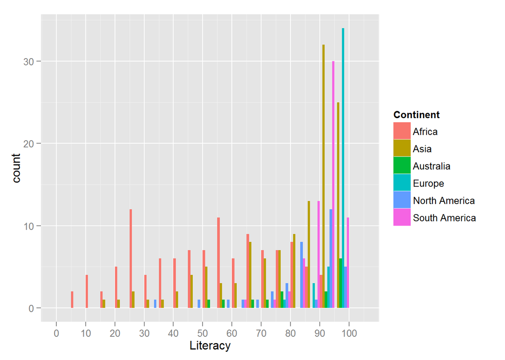

```
## Continent: Africa
##    Min. 1st Qu.  Median    Mean 3rd Qu.    Max.
##   8.685  34.780  55.240  53.650  71.570  93.100
## --------------------------------------------------------
## Continent: Asia
##    Min. 1st Qu.  Median    Mean 3rd Qu.    Max.
##   18.16   70.29   88.69   80.33   93.62   99.78
## --------------------------------------------------------
## Continent: Australia
##    Min. 1st Qu.  Median    Mean 3rd Qu.    Max.
##   52.87   74.65   92.19   84.42   98.39   99.59
## --------------------------------------------------------
## Continent: Europe
##    Min. 1st Qu.  Median    Mean 3rd Qu.    Max.
##   79.44   96.23   97.94   96.51   99.22   99.82
## --------------------------------------------------------
## Continent: North America
##    Min. 1st Qu.  Median    Mean 3rd Qu.    Max.
##   34.73   79.44   85.83   83.37   92.96   99.80
## --------------------------------------------------------
## Continent: South America
##    Min. 1st Qu.  Median    Mean 3rd Qu.    Max.
##   63.21   88.24   91.15   90.32   93.78   98.65
```

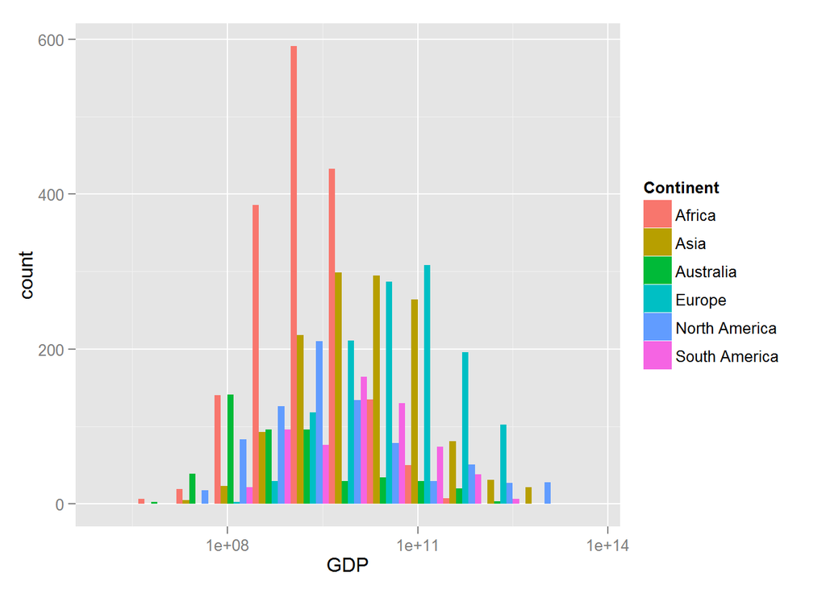

```
## Continent: Africa
##      Min.   1st Qu.    Median      Mean   3rd Qu.      Max.
## 9.123e+06 7.609e+08 2.179e+09 9.902e+09 6.361e+09 4.166e+11
## --------------------------------------------------------
## Continent: Asia
##      Min.   1st Qu.    Median      Mean   3rd Qu.      Max.
## 4.246e+07 3.921e+09 1.795e+10 1.877e+11 8.679e+10 7.322e+12
## --------------------------------------------------------
## Continent: Australia
##      Min.   1st Qu.    Median      Mean   3rd Qu.      Max.
## 1.430e+07 1.471e+08 5.264e+08 3.766e+10 3.656e+09 1.388e+12
## --------------------------------------------------------
## Continent: Europe
##      Min.   1st Qu.    Median      Mean   3rd Qu.      Max.
## 2.484e+08 1.228e+10 5.771e+10 2.668e+11 2.377e+11 3.752e+12
## --------------------------------------------------------
## Continent: North America
##      Min.   1st Qu.    Median      Mean   3rd Qu.      Max.
## 2.807e+07 7.726e+08 3.161e+09 4.427e+11 2.002e+10 1.552e+13
## --------------------------------------------------------
## Continent: South America
##      Min.   1st Qu.    Median      Mean   3rd Qu.      Max.
## 9.385e+07 1.959e+09 9.179e+09 7.054e+10 3.873e+10 2.477e+12
```

GDP Histogram filled by Continents.

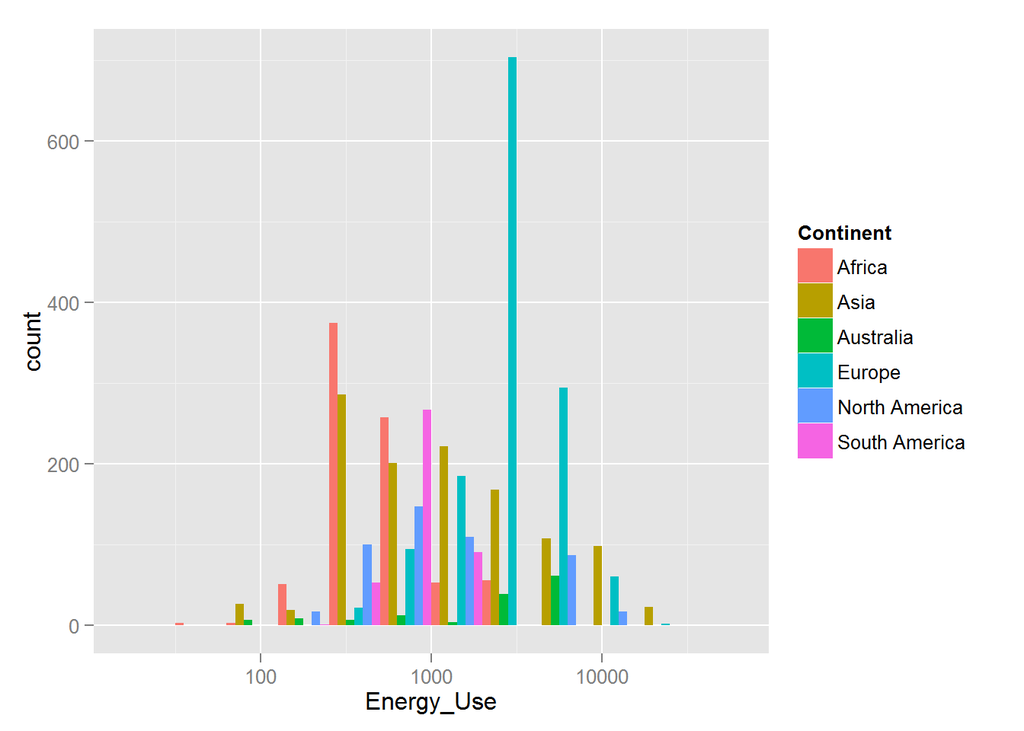

```
## Continent: Africa
##    Min. 1st Qu.  Median    Mean 3rd Qu.    Max.
##   43.23  376.00  453.80  684.50  762.70 3103.00
## --------------------------------------------------------
## Continent: Asia
##     Min.  1st Qu.   Median     Mean  3rd Qu.     Max.
##    85.45   456.50  1131.00  2683.00  2956.00 23110.00
## --------------------------------------------------------
## Continent: Australia
##    Min. 1st Qu.  Median    Mean 3rd Qu.    Max.
##   88.43 1751.00 3578.00 3105.00 4526.00 5766.00
## --------------------------------------------------------
## Continent: Europe
##    Min. 1st Qu.  Median    Mean 3rd Qu.    Max.
##   289.1  2106.0  2980.0  3364.0  4050.0 16900.0
## --------------------------------------------------------
## Continent: North America
##    Min. 1st Qu.  Median    Mean 3rd Qu.    Max.
##   186.8   502.1   750.2  2191.0  1530.0  8438.0
## --------------------------------------------------------
## Continent: South America
##    Min. 1st Qu.  Median    Mean 3rd Qu.    Max.
##   236.2   620.6   731.7   845.4   940.6  1967.0
```

Energy use histogram by Continents.

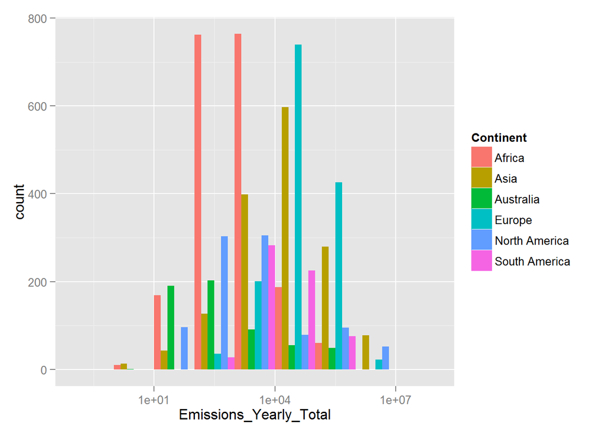

```
## Continent: Africa
##     Min.  1st Qu.   Median     Mean  3rd Qu.     Max.
##      3.7    399.7   1060.0  13090.0   3957.0 519300.0
## --------------------------------------------------------
## Continent: Asia
##    Min. 1st Qu.  Median    Mean 3rd Qu.    Max.
##       4    3638   22490  187000   81510 9111000
## --------------------------------------------------------
## Continent: Australia
##     Min.  1st Qu.   Median     Mean  3rd Qu.     Max.
##      7.3     66.0    198.0  24170.0   2009.0 400200.0
## --------------------------------------------------------
## Continent: Europe
##      Min.   1st Qu.    Median      Mean   3rd Qu.      Max.
##     293.3   17550.0   54850.0  144800.0  164100.0 1121000.0
## --------------------------------------------------------
## Continent: North America
##    Min. 1st Qu.  Median    Mean 3rd Qu.    Max.
##      11     407    1764  305200    8726 5828000
## --------------------------------------------------------
## Continent: South America
##     Min.  1st Qu.   Median     Mean  3rd Qu.     Max.
##    304.3   2392.0   9165.0  39280.0  44820.0 424400.0
```

and for the emissions capita,

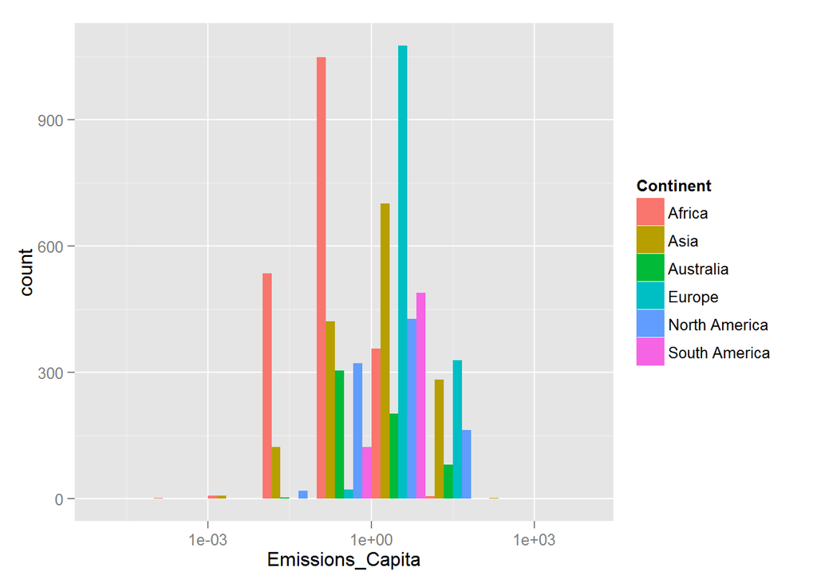

As expected, Europe and North America contribute a lot along with Asia with the remaining countinents contributing relatively little.

Subsetting the year by 2000 to see if individual year follows general trend

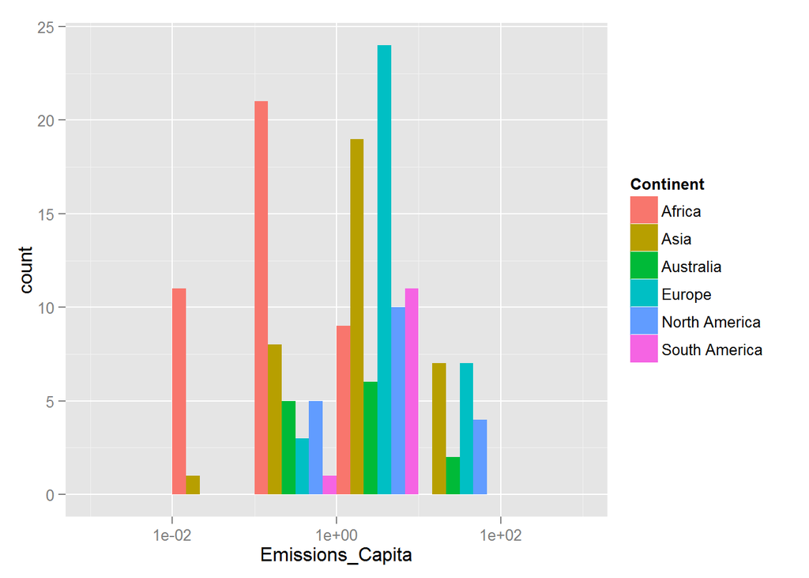

Doing the same for emissions Yearly

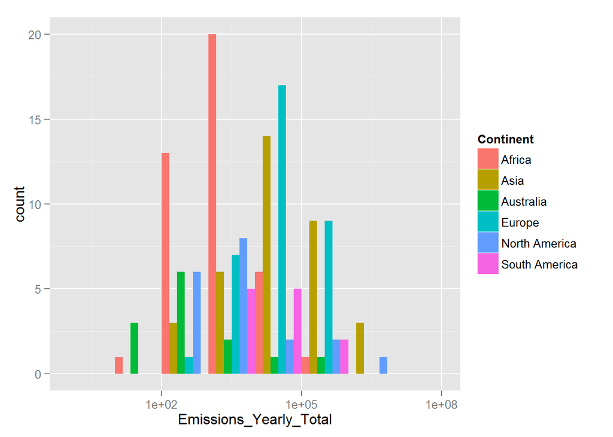

As expected both histograms show a similar pattern to that seen for the overall, taking into account of course that a handful of countries are emitting more in subsequent years. A bar chart showing the emissions for each continent might help.

In an earlier histogram, we saw how different continents contribute to the global emissions. Continents like Asia for example show a very wide spread, implying there are countries within the continent across the entire spectrum low to high emissions. It would be helpful to know exactly which countries within which continents are driving up the total emissions for a particular continent and which ones are contributing less. A heat map can help visualize this and it can also show how it has changed across the years.

Bar Charts for both emission yearly by continent

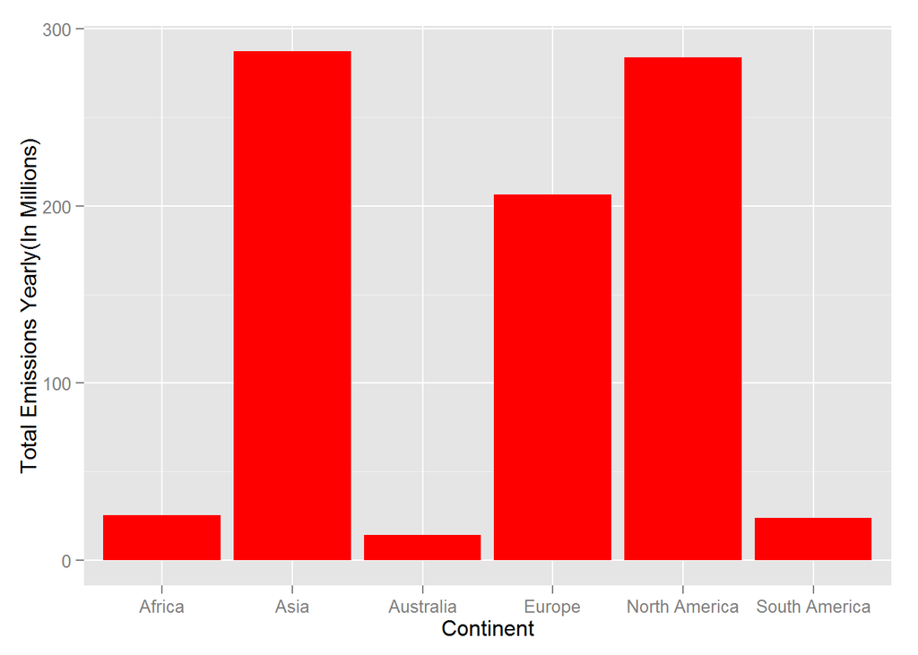

```
## Continent: Africa
## [1] 25.5503
## --------------------------------------------------------
## Continent: Asia
## [1] 287.259
## --------------------------------------------------------
## Continent: Australia
## [1] 14.23509
## --------------------------------------------------------
## Continent: Europe
## [1] 206.3275
## --------------------------------------------------------
## Continent: North America
## [1] 283.8233
## --------------------------------------------------------
## Continent: South America
## [1] 24.03916
```

For emissions per capita

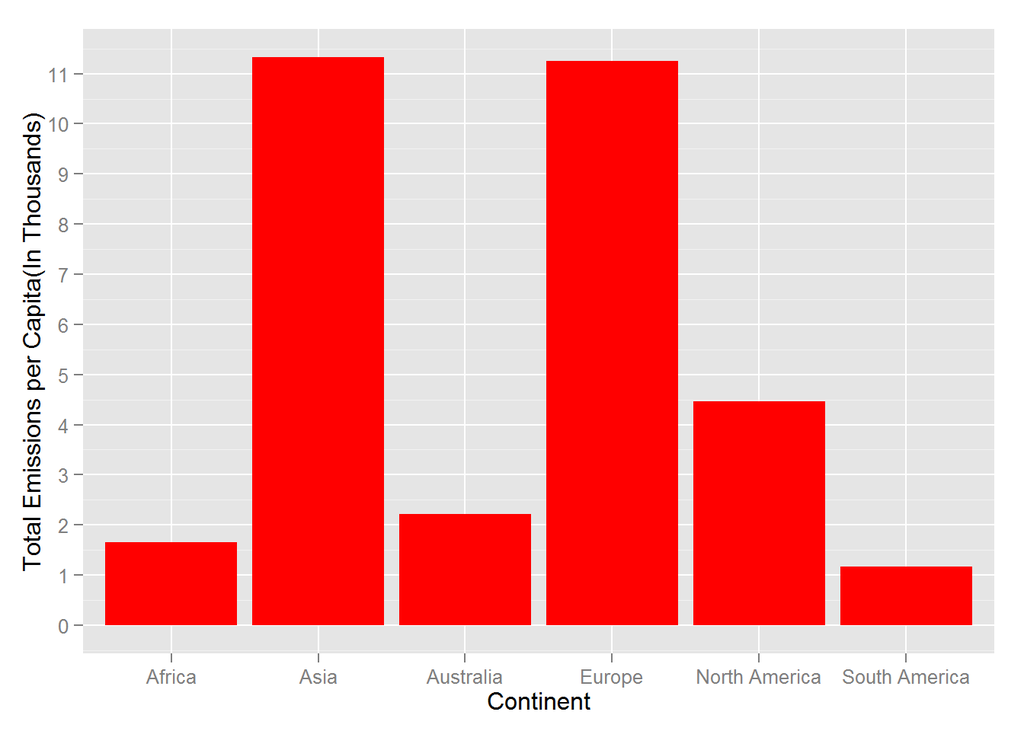

```
## Continent: Africa
## [1] 1.659887
## --------------------------------------------------------
## Continent: Asia
## [1] 11.32526
## --------------------------------------------------------
## Continent: Australia
## [1] 2.217393
## --------------------------------------------------------
## Continent: Europe
## [1] 11.25941
## --------------------------------------------------------
## Continent: North America
## [1] 4.461792
## --------------------------------------------------------
## Continent: South America
## [1] 1.175001
```

The bar chart for Emissions capita by continent tells a slightly different story, Africa and South America remain relatively low with Australia slightly higher than both. Europe and Asia are quite high, higher even than North America. The emissions per capita measures each country’s emission divided by the population thereby showing the average emissions per person.

It would be interesting to see exactly what the distribution is like for each continent for both the yearly and per capita emissions. A boxplot would be ideal for this since it shows the range as well as the IQR. Also included is a point for the mean though the median is more ideal for this distribution due to outliers.

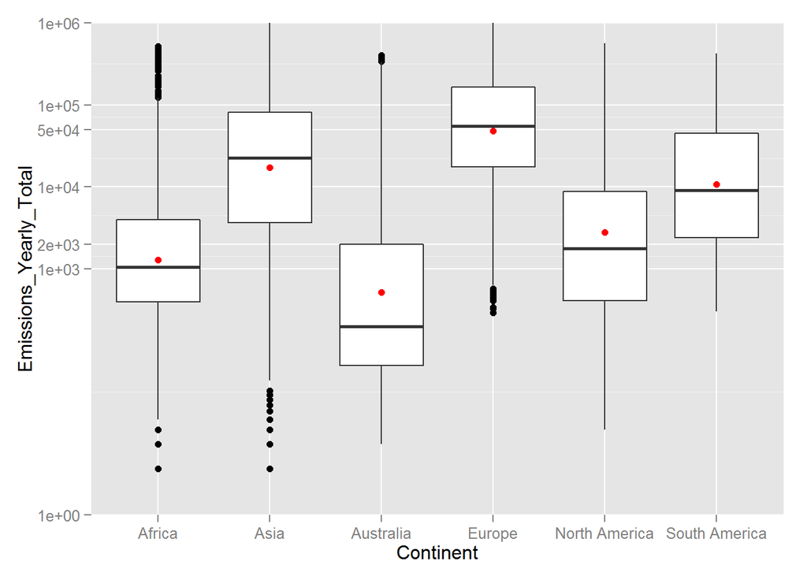

```
## Continent: Africa
##     Min.  1st Qu.   Median     Mean  3rd Qu.     Max.
##      3.7    399.7   1060.0  13090.0   3957.0 519300.0
## --------------------------------------------------------
## Continent: Asia
##    Min. 1st Qu.  Median    Mean 3rd Qu.    Max.
##       4    3638   22490  187000   81510 9111000
## --------------------------------------------------------
## Continent: Australia
##     Min.  1st Qu.   Median     Mean  3rd Qu.     Max.
##      7.3     66.0    198.0  24170.0   2009.0 400200.0
## --------------------------------------------------------
## Continent: Europe
##      Min.   1st Qu.    Median      Mean   3rd Qu.      Max.
##     293.3   17550.0   54850.0  144800.0  164100.0 1121000.0
## --------------------------------------------------------
## Continent: North America
##    Min. 1st Qu.  Median    Mean 3rd Qu.    Max.
##      11     407    1764  305200    8726 5828000
## --------------------------------------------------------
## Continent: South America
##     Min.  1st Qu.   Median     Mean  3rd Qu.     Max.
##    304.3   2392.0   9165.0  39280.0  44820.0 424400.0
```

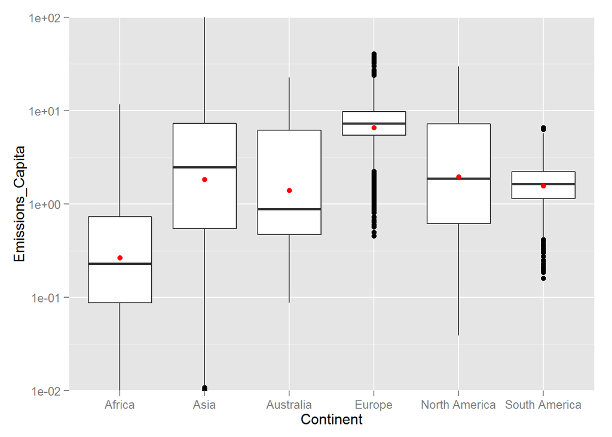

```
## Continent: Africa
##      Min.   1st Qu.    Median      Mean   3rd Qu.      Max.
##  0.000557  0.087680  0.231100  0.850400  0.731600 11.720000
## --------------------------------------------------------
## Continent: Asia
##      Min.   1st Qu.    Median      Mean   3rd Qu.      Max.
##   0.00451   0.54300   2.48400   7.37300   7.32500 101.90000
## --------------------------------------------------------
## Continent: Australia
##     Min.  1st Qu.   Median     Mean  3rd Qu.     Max.
##  0.08705  0.47020  0.88450  3.76500  6.18700 22.77000
## --------------------------------------------------------
## Continent: Europe
##    Min. 1st Qu.  Median    Mean 3rd Qu.    Max.
##  0.4542  5.4340  7.2930  7.9010  9.7730 40.5300
## --------------------------------------------------------
## Continent: North America
##     Min.  1st Qu.   Median     Mean  3rd Qu.     Max.
##  0.03892  0.62010  1.87600  4.79800  7.22300 29.84000
## --------------------------------------------------------
## Continent: South America
##    Min. 1st Qu.  Median    Mean 3rd Qu.    Max.
##  0.1597  1.1390  1.6390  1.9200  2.2090  6.5810
```

Both have lots of outliers with europe showing the highest per capita alongside Asia with Australia and North America closely behind. Just as in the case of the bar charts, the emissions yearly with continents boxplot is slightly different, Australia and North America emitts comparatively little with Europe still showing pretty high. One reason for this is that since Europe consists of many countries that contribute a fair bit in addition to a number of countries that contribute a lot mixed with Europe’s relatively small population drives up the per capita emission for Europe.

What Continents are contributing the most to the global population?

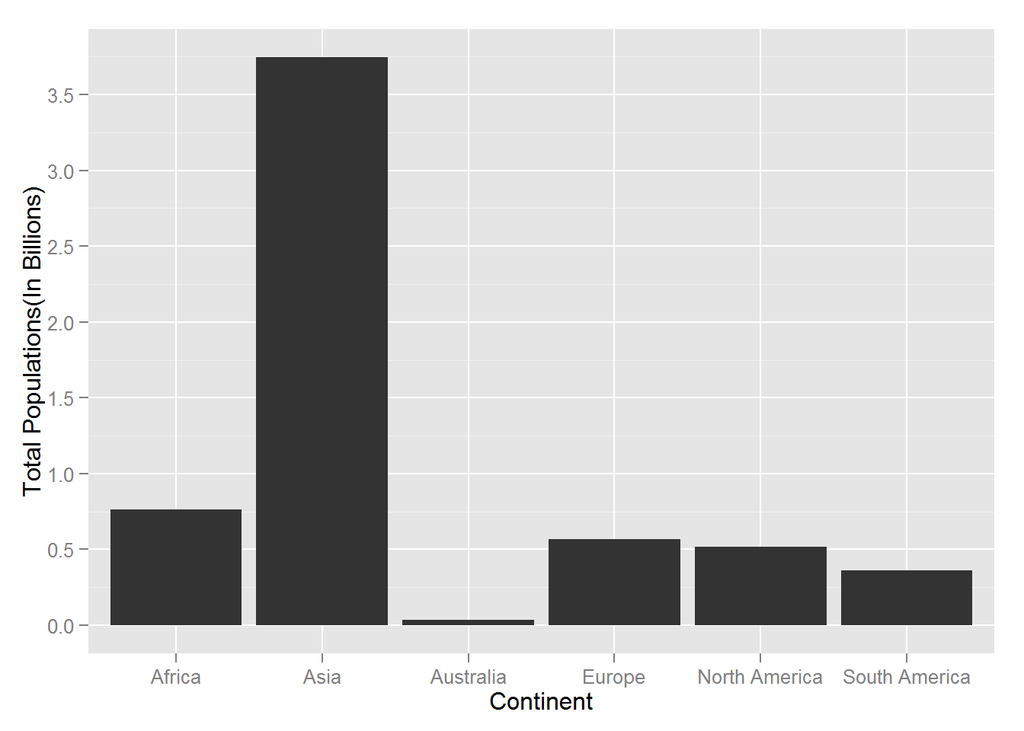

```
## Continent: Africa
## [1] 0.7612663
## --------------------------------------------------------
## Continent: Asia
## [1] 3.745741
## --------------------------------------------------------
## Continent: Australia
## [1] 0.0355108
## --------------------------------------------------------
## Continent: Europe
## [1] 0.5661809
## --------------------------------------------------------
## Continent: North America
## [1] 0.5162328
## --------------------------------------------------------
## Continent: South America
## [1] 0.3631531
```

As expected, Asia contributes a large amount, this is definitely due to contries like India and China both being a part of the continent. Again, this sums up the populations for all the countries we have for every year we have.

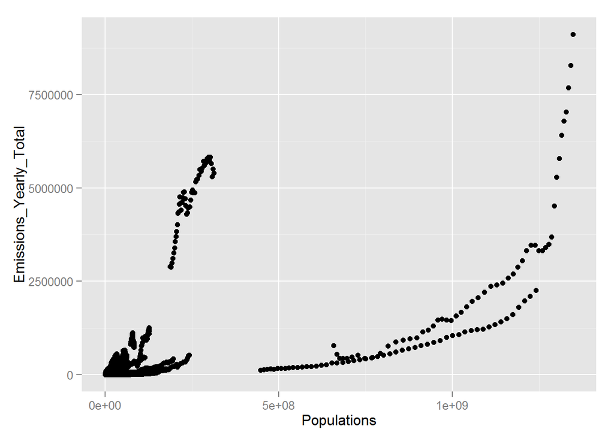

A scatterplot of Emissions yearly and populations is irregularly shaped but it does show a pattern, applying the log function to both axis results in a more linearly shaped plot with an increase as well in the correlation score of 0.75

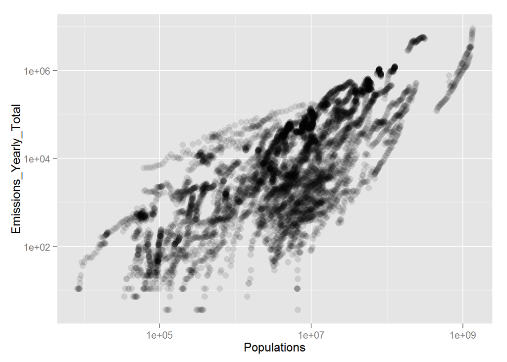

```
##
##  Pearson's product-moment correlation
##
## data:  log10(Populations) and log10(Emissions_Yearly_Total)
## t = 95.45, df = 7042, p-value < 2.2e-16
## alternative hypothesis: true correlation is not equal to 0
## 95 percent confidence interval:
##  0.7406611 0.7610299
## sample estimates:
##       cor
## 0.7510241
```

How has emissions yearly changed over the years?

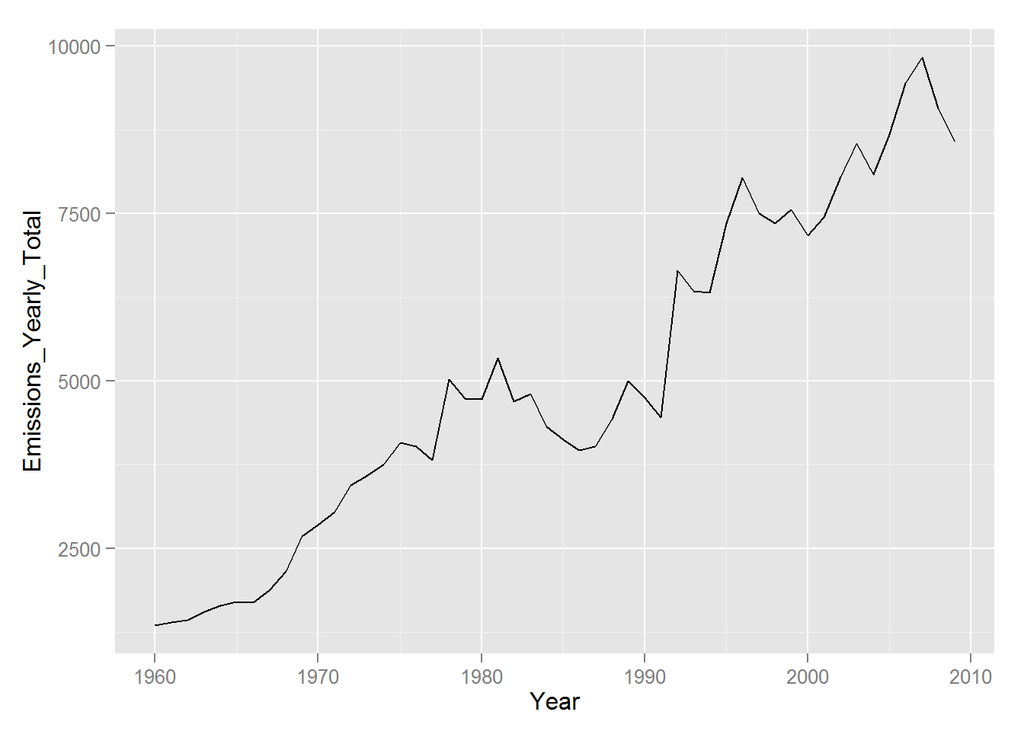

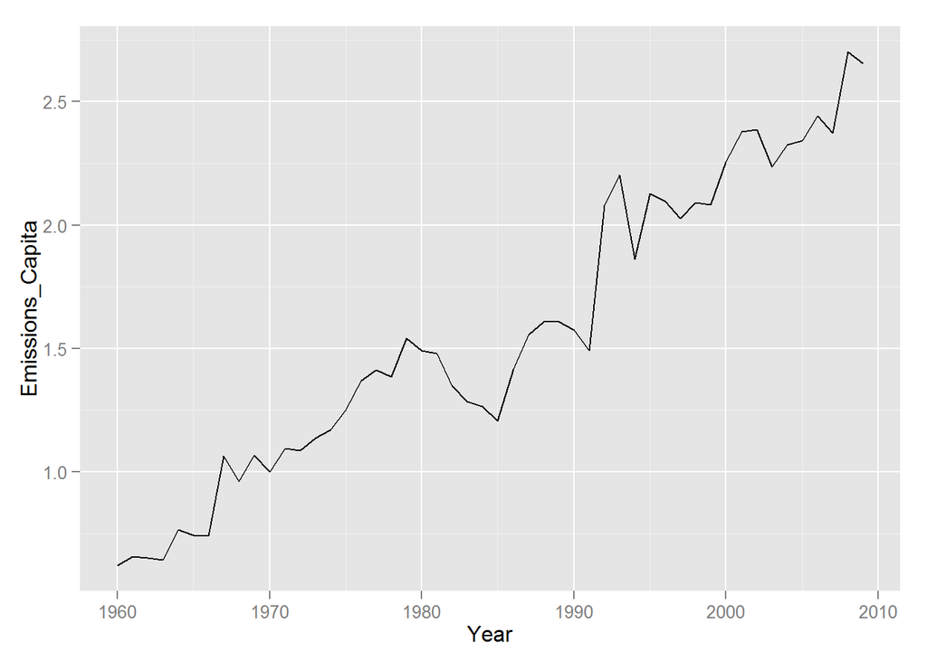

There seems to have been an increase.

Does a higher literacy rate result in more or lower carbon emission?

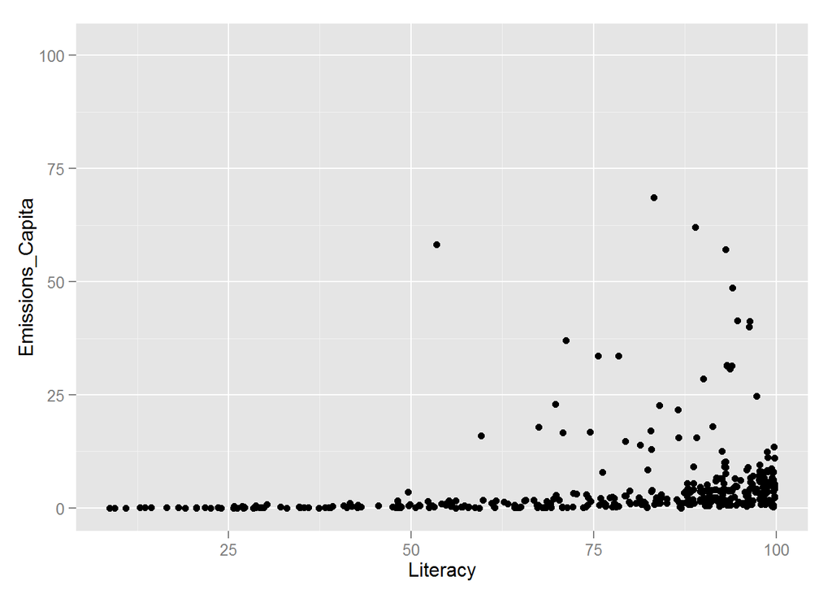

```
##
##  Pearson's product-moment correlation
##
## data:  Literacy and Emissions_Capita
## t = 4.7915, df = 390, p-value = 2.357e-06
## alternative hypothesis: true correlation is not equal to 0
## 95 percent confidence interval:
##  0.1400088 0.3271941
## sample estimates:
##       cor
## 0.2357872
```

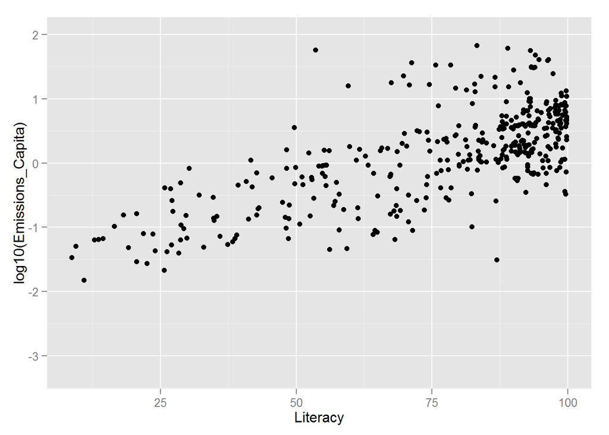

```
##
##  Pearson's product-moment correlation
##
## data:  Literacy and log10(Emissions_Capita)
## t = 19.54, df = 390, p-value < 2.2e-16
## alternative hypothesis: true correlation is not equal to 0
## 95 percent confidence interval:
##  0.6495477 0.7501352
## sample estimates:
##       cor
## 0.7033452
```

An initial plot without transformation didn’t show much of a trend and also gave a cor test of 0.2, however, applying a log transformation to the emissions capita resulted in much better R2 of 0.7. This shows a positive correlation between literacy and per capita emissions.

Does more energy use mean a high rate of emission?

```
##
##  Pearson's product-moment correlation
##
## data:  Energy_Use and Emissions_Capita
## t = 108.55, df = 4336, p-value < 2.2e-16
## alternative hypothesis: true correlation is not equal to 0
## 95 percent confidence interval:
##  0.8467701 0.8627911
## sample estimates:
##       cor
## 0.8549844
```

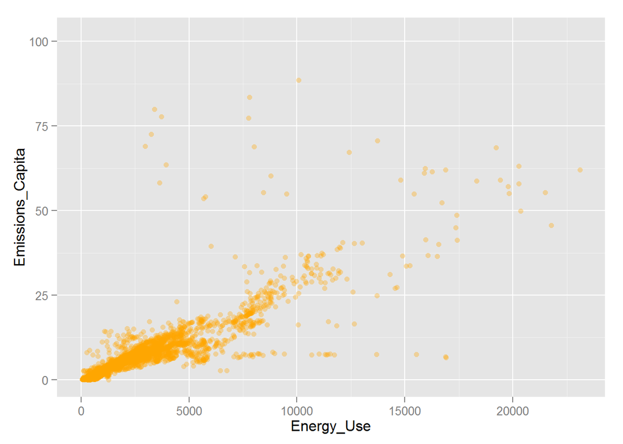

```
##
##  Pearson's product-moment correlation
##
## data:  log10(Energy_Use) and log10(Emissions_Capita)
## t = 142.94, df = 4336, p-value < 2.2e-16
## alternative hypothesis: true correlation is not equal to 0
## 95 percent confidence interval:
##  0.9029092 0.9133361
## sample estimates:
##       cor
## 0.9082636
```

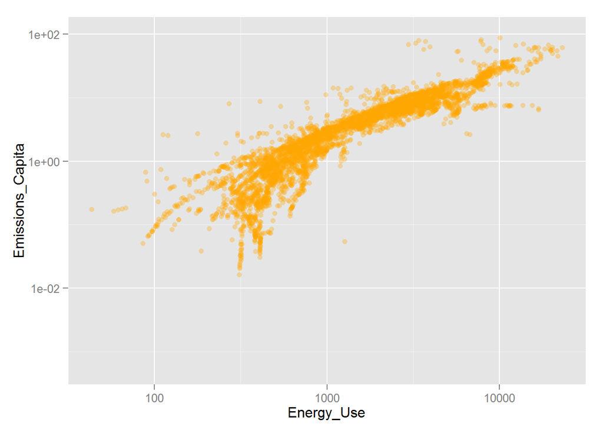

There is a very high correlation between these two features with a correlation score of 0.85 without any transformations and a score of 0.9 with.

```
##
##  Pearson's product-moment correlation
##
## data:  GDP and Emissions_Yearly_Total
## t = 93.493, df = 6225, p-value < 2.2e-16
## alternative hypothesis: true correlation is not equal to 0
## 95 percent confidence interval:
##  0.7537035 0.7743738
## sample estimates:
##       cor
## 0.7642348
```

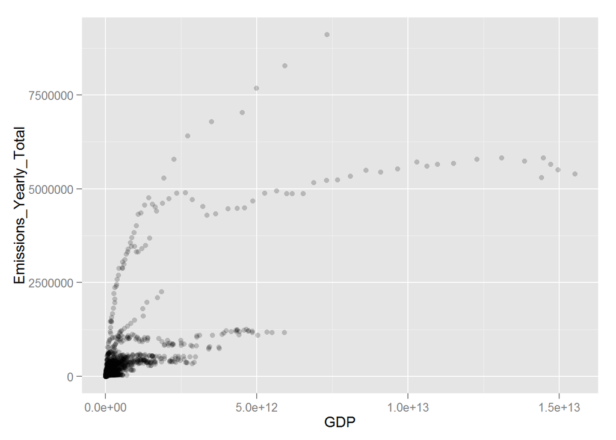

```
##
##  Pearson's product-moment correlation
##
## data:  log10(GDP) and log10(Emissions_Yearly_Total)
## t = 201.58, df = 6225, p-value < 2.2e-16
## alternative hypothesis: true correlation is not equal to 0
## 95 percent confidence interval:
##  0.9278324 0.9344354
## sample estimates:
##       cor
## 0.9312102
```

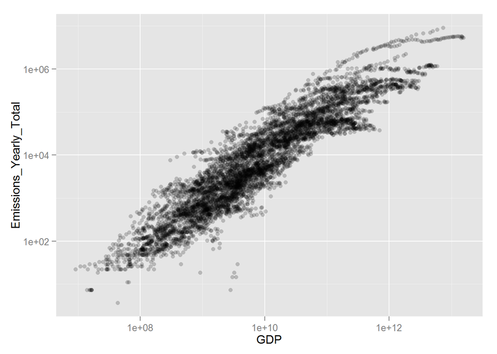

There is a high positive correlation between Energy use and emissions capita, and as well as between GDP and emissions yearly, this increases to 0.9 when a log transformation is applied to both variables.

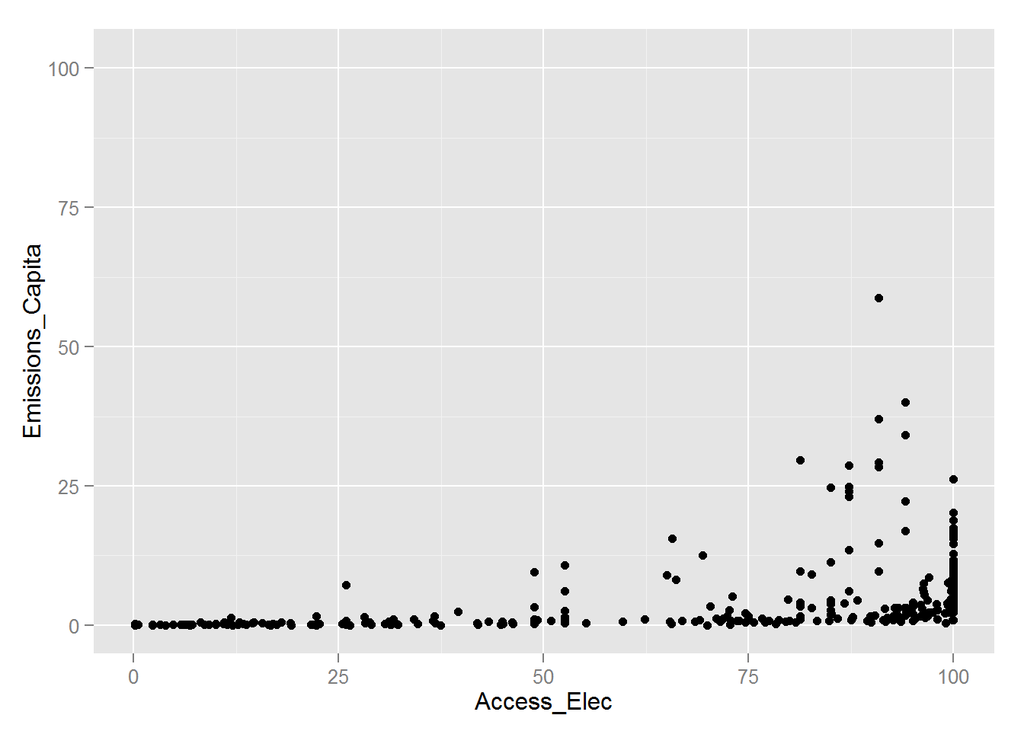

```
##
##  Pearson's product-moment correlation
##
## data:  Access_Elec and Emissions_Capita
## t = 8.7765, df = 343, p-value < 2.2e-16
## alternative hypothesis: true correlation is not equal to 0
## 95 percent confidence interval:
##  0.3379282 0.5107302
## sample estimates:
##      cor
## 0.428236
```

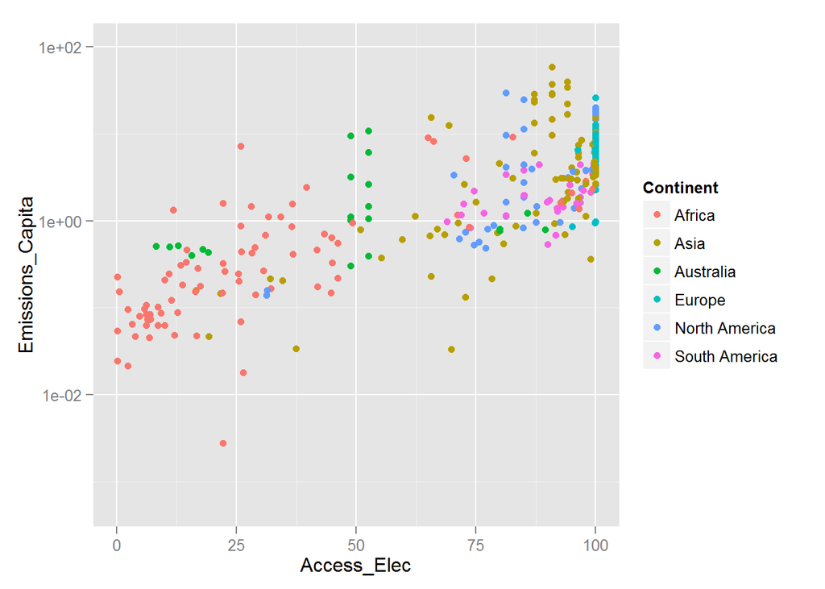

```
##
##  Pearson's product-moment correlation
##
## data:  Access_Elec and log10(Emissions_Capita)
## t = 24.975, df = 343, p-value < 2.2e-16
## alternative hypothesis: true correlation is not equal to 0
## 95 percent confidence interval:
##  0.7623081 0.8377763
## sample estimates:
##       cor
## 0.8032425
```

There is also a strongly correlated relationship between Percentage with access to electricity and Emissions per capita.